# Analise dos gastos dos parlamentares

Rafaelle Amorim

15 de julho de 2016

```r
knitr::opts_chunk$set(echo=TRUE, warning=FALSE, message=FALSE, fig.width=12, fig.height=6)
```

Para o checkpoint 4 utilizaremos os dados coletados do site de tranparência da câmara dos deputados. Esses dados são referentes aos gastos dos deputados em 2016 e são compostos por 572 parlamentares.

```r
gastos = read.csv("../dados/ano-atual.csv",  encoding="UTF-8")
cotas = read.csv("../dados/valor-cota-por-estado.csv",  encoding="UTF-8")
```

Inicialmente iremos analisar a categoria de “Emissão Bilhete Aéreo”, que diferente da categoria “Passagens Aéreas”, possui apenas dados de 2016, para tentar responder a pergunta “Como é distribuído a quantidade de pessoas que viajam com o nome dos Deputados?”

Para melhor compreensão dos dados, usaremos apenas os gastos com “valor liquido” positivo, pois os valores negativos significam que o referido bilhete é um bilhete de compensação, pois compensa um outro bilhete emitido e não utilizado pelo deputado.

```r
emissao.bilhete.aereo = gastos %>%
  group_by(txtDescricao) %>%
  filter(txtDescricao == "Emissão Bilhete Aéreo" & vlrLiquido >= 0)

bilhete.aereo.por.deputado = emissao.bilhete.aereo %>%
  group_by(txNomeParlamentar) %>%
  summarise(total.passageiros = length(unique(txtPassageiro)), total.vlrLiquido = sum(vlrLiquido), gasto.medio.bilhete = mean(total.vlrLiquido/length(unique(txtNumero))))  %>%
  arrange(-total.passageiros)


#summary(bilhete.aereo.por.deputado$total.passageiros)
```

Tivemos um total de 517 observações, iremos avaliar o total do gasto liquido de cada deputado em relação a quantidade de passageiros:

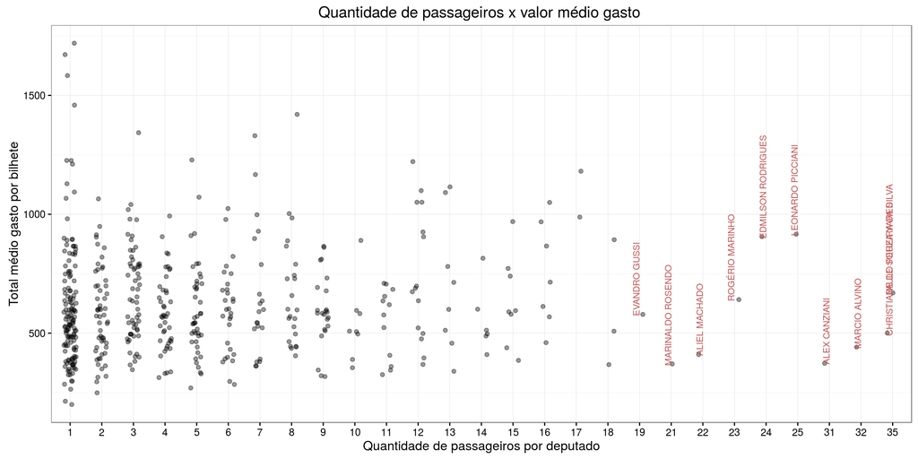

```r
ggplot(bilhete.aereo.por.deputado, aes( as.factor(total.passageiros), gasto.medio.bilhete ))+
  geom_point(position = position_jitter(width = .5), alpha = .4) +
  geom_text(aes(label=ifelse(bilhete.aereo.por.deputado$total.passageiros > 18, as.character(txNomeParlamentar), '')), hjust=.02, vjust=0, angle = 90, size =3, color = "#c35656") +
  ylab("Total médio gasto por bilhete") +
  xlab("Quantidade de passageiros por deputado") +
  ggtitle("Quantidade de passageiros x valor médio gasto ") +
  geom_smooth(stat="smooth")
```

```r
#AJUSTAR
```

Podemos perceber que existe uma grande concentração de parlamentares com apenas um passageiro, assim como a grande maioria da média de gasto por bilhete está abaixo de R$1000

pergunta 2 - Quais são os estados que gastam mais? E os que economizam?

Primeiramente, iremos agrupar os deputados por estado, obtendo assim, o valor total gasto por cada estado, a média de gasto, e a cota de cada deputado por estado

```r
gastos = left_join(gastos, cotas, by = c("sgUF" = "estado"))

gasto.por.estado = gastos %>%
  group_by(sgUF) %>%
  summarise(total.gasto = sum(vlrLiquido), media.gasto = mean(vlrLiquido), numDeputados = length(unique(txNomeParlamentar)), valor.por.cota = sum(total.gasto/valor))
```

Em um primeiro momento, percebemos que existe o valor NA (not available) nos estados, investigando melhor, descobrimos que são gastos partidarios, portanto, sem estado definido.

Para a análise, não iremos nos atar a esses dados, mas iremos mostrar resumidamente como os dados se comportam:

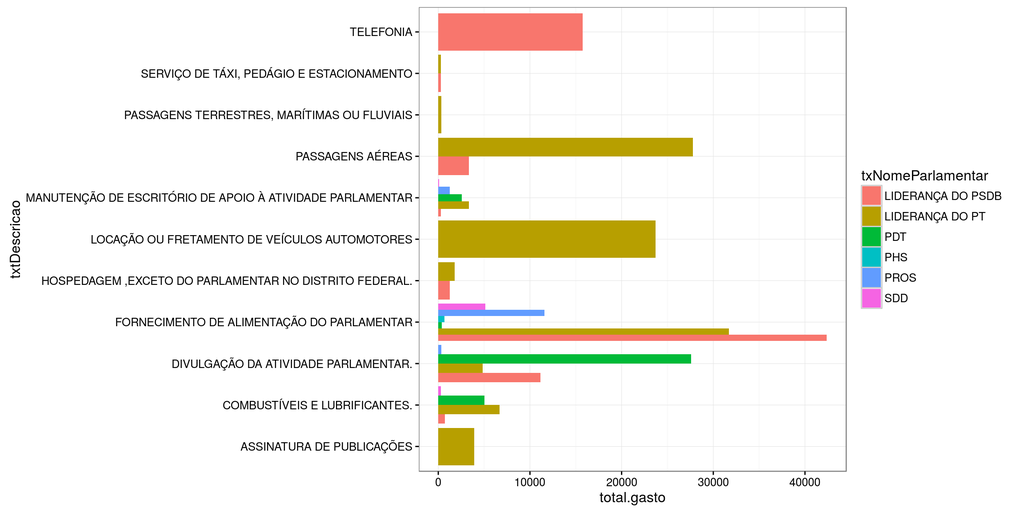

```r
gasto.partidario = gastos %>%
  filter(is.na(sgUF)) %>%
  group_by(txNomeParlamentar, txtDescricao)  %>%
  summarise(total.gasto = sum(vlrLiquido))

ggplot(gasto.partidario, aes(txtDescricao, total.gasto ,fill = txNomeParlamentar)) +
  geom_bar(stat = "identity" , position = "dodge") + coord_flip()
```

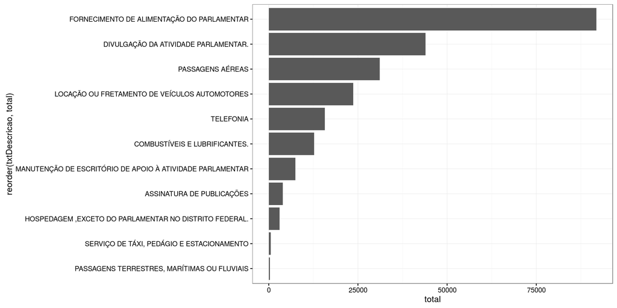

```r
total.gasto.partidario = gasto.partidario %>%
    group_by(txtDescricao)  %>%
  summarise(total = sum(total.gasto))

ggplot(total.gasto.partidario, aes(reorder(txtDescricao, total), total)) +
  geom_bar(stat = "identity") +
  coord_flip()
```

```r
summary(gasto.partidario$total.gasto)
```

```
##    Min. 1st Qu.  Median    Mean 3rd Qu.    Max.
##    84.0   368.2  3321.0  8082.0 11150.0 42390.0
```

```r
sd(gasto.partidario$total.gasto)
```

```
## [1] 11465.93
```

Como podemos perceber, a maior parte dos gastos é com “Fornecimento de Alimentação do Parlamentar”, a média de gasto é de R$8082,00 com desvio padrão (quão distantes os valores estão da média) de R$ 11465,93, um valor bastante alto, o que indica que os valores não estão muito concentrados em uma faixa de valor.

Para tentar melhorar a precisão iremos dividir o total do valor liquido de cada parlamentar por sua cota, assim, teremos o valor gasto com relação à cota.

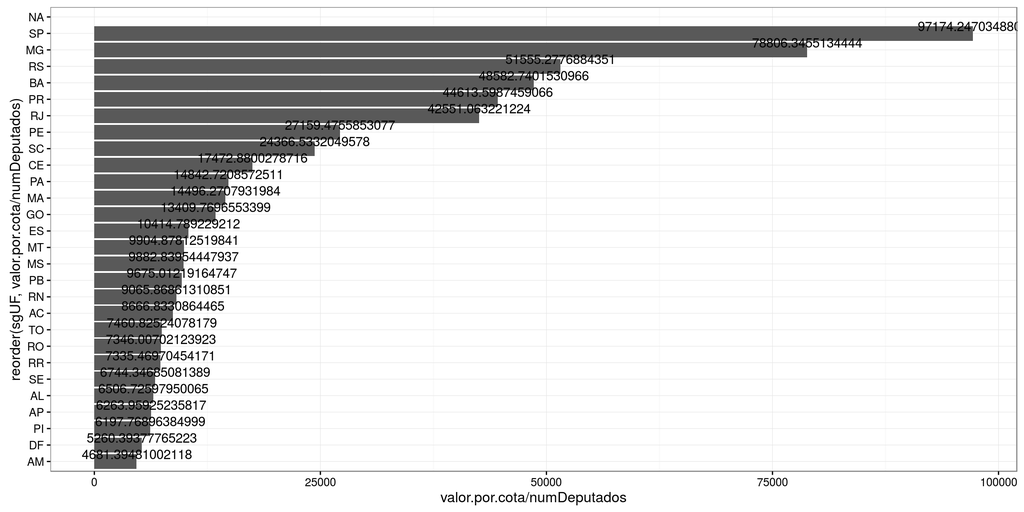

```r
ggplot(gasto.por.estado, aes(reorder(sgUF, valor.por.cota/numDeputados), valor.por.cota/numDeputados)) +
  geom_bar(stat = "identity") +
  coord_flip() +
  geom_text(aes(label=valor.por.cota/numDeputados), position=position_dodge(width=0.9), vjust=-0.25)
```